# Ejercicios de la práctica del día 5 de Mayo

> Por Ana Buendía Ruiz-Azuaga Creado el 12 de Mayo

```r
hatco <- read.csv(file="hatco2.csv", header=TRUE, as.is=NA)
```

## Ejercicio 1

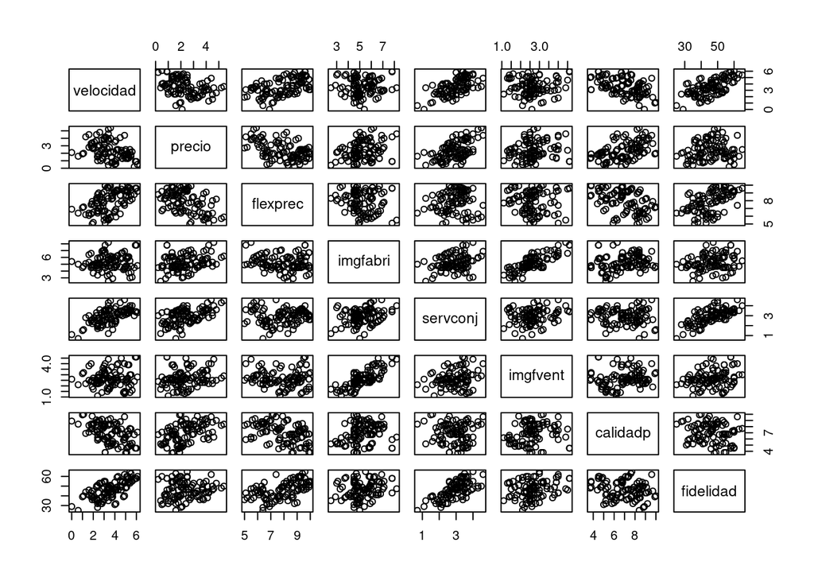

```r
plot(hatco[,c(6:13)])
```

Parece que velocidad y fidelidad tiene relacion lineal, asi com calidad y velocidad

## Ejercicio 2

```r
mod1<-lm(fidelidad~velocidad+precio+flexprec+imgfabri+servconj+imgfvent+calidadp,hatco)
mod1
```

```
##
## Call:
## lm(formula = fidelidad ~ velocidad + precio + flexprec + imgfabri +
##     servconj + imgfvent + calidadp, data = hatco)
##
## Coefficients:
## (Intercept)    velocidad       precio     flexprec     imgfabri     servconj
##   -10.16148     -0.04352     -0.67891      3.36197     -0.04101      8.34537
##    imgfvent     calidadp
##     1.29147      0.56295
```

```r
summary(mod1)
```

```
##
## Call:
## lm(formula = fidelidad ~ velocidad + precio + flexprec + imgfabri +
##     servconj + imgfvent + calidadp, data = hatco)
##
## Residuals:
##      Min       1Q   Median       3Q      Max
## -12.9759  -1.9491   0.5896   2.8144   6.7565
##
## Coefficients:
##              Estimate Std. Error t value Pr(>|t|)
## (Intercept) -10.16148    4.97696  -2.042   0.0440 *
## velocidad    -0.04352    2.01273  -0.022   0.9828
## precio       -0.67891    2.09025  -0.325   0.7461
## flexprec      3.36197    0.41125   8.175 1.56e-12 ***
## imgfabri     -0.04101    0.66683  -0.061   0.9511
## servconj      8.34537    3.91830   2.130   0.0359 *
## imgfvent      1.29147    0.94720   1.363   0.1761
## calidadp      0.56295    0.35544   1.584   0.1167
## ---
## Signif. codes:  0 '***' 0.001 '**' 0.01 '*' 0.05 '.' 0.1 ' ' 1
##
## Residual standard error: 4.424 on 92 degrees of freedom
## Multiple R-squared:  0.775,  Adjusted R-squared:  0.7578
## F-statistic: 45.26 on 7 and 92 DF,  p-value: < 2.2e-16
```

```r
anova(mod1)
```

```
## Analysis of Variance Table
##
## Response: fidelidad
##           Df Sum Sq Mean Sq  F value    Pr(>F)
## velocidad  1 3659.8  3659.8 187.0071 < 2.2e-16 ***
## precio     1  927.9   927.9  47.4128 6.932e-10 ***
## flexprec   1 1346.3  1346.3  68.7912 8.779e-13 ***
## imgfabri   1  100.4   100.4   5.1311   0.02585 *
## servconj   1   71.5    71.5   3.6517   0.05913 .
## imgfvent   1   44.9    44.9   2.2963   0.13311
## calidadp   1   49.1    49.1   2.5084   0.11667
## Residuals 92 1800.5    19.6
## ---
## Signif. codes:  0 '***' 0.001 '**' 0.01 '*' 0.05 '.' 0.1 ' ' 1
```

## Ejercicio 3

```r
mod2<-lm(fidelidad~precio+flexprec+imgfabri+servconj+imgfvent+calidadp,hatco)
mod2
```

```
##
## Call:
## lm(formula = fidelidad ~ precio + flexprec + imgfabri + servconj +
##     imgfvent + calidadp, data = hatco)
##
## Coefficients:
## (Intercept)       precio     flexprec     imgfabri     servconj     imgfvent
##   -10.18357     -0.63566      3.36213     -0.03886      8.26256      1.29024
##    calidadp
##     0.56283
```

```r
summary(mod2)
```

```
##
## Call:
## lm(formula = fidelidad ~ precio + flexprec + imgfabri + servconj +
##     imgfvent + calidadp, data = hatco)
##
## Residuals:
##      Min       1Q   Median       3Q      Max
## -12.9771  -1.9500   0.5889   2.7784   6.7579
##
## Coefficients:
##              Estimate Std. Error t value Pr(>|t|)
## (Intercept) -10.18357    4.84472  -2.102   0.0383 *
## precio       -0.63566    0.60402  -1.052   0.2954
## flexprec      3.36213    0.40896   8.221 1.17e-12 ***
## imgfabri     -0.03886    0.65587  -0.059   0.9529
## servconj      8.26256    0.82179  10.054  < 2e-16 ***
## imgfvent      1.29024    0.94040   1.372   0.1734
## calidadp      0.56283    0.35348   1.592   0.1147
## ---
## Signif. codes:  0 '***' 0.001 '**' 0.01 '*' 0.05 '.' 0.1 ' ' 1
##
## Residual standard error: 4.4 on 93 degrees of freedom
## Multiple R-squared:  0.7749, Adjusted R-squared:  0.7604
## F-statistic: 53.37 on 6 and 93 DF,  p-value: < 2.2e-16
```

```r
anova(mod2)
```

```
## Analysis of Variance Table
##
## Response: fidelidad
##           Df Sum Sq Mean Sq  F value    Pr(>F)
## precio     1   55.0    55.0   2.8412 0.0952300 .
## flexprec   1 3757.0  3757.0 194.0641 < 2.2e-16 ***
## imgfabri   1  310.9   310.9  16.0604 0.0001236 ***
## servconj   1 1982.6  1982.6 102.4082 < 2.2e-16 ***
## imgfvent   1   45.1    45.1   2.3309 0.1302240
## calidadp   1   49.1    49.1   2.5352 0.1147258
## Residuals 93 1800.5    19.4
## ---
## Signif. codes:  0 '***' 0.001 '**' 0.01 '*' 0.05 '.' 0.1 ' ' 1
```

## Ejercicio 4

```r
summary(mod1)
```

```
##
## Call:
## lm(formula = fidelidad ~ velocidad + precio + flexprec + imgfabri +
##     servconj + imgfvent + calidadp, data = hatco)
##
## Residuals:
##      Min       1Q   Median       3Q      Max
## -12.9759  -1.9491   0.5896   2.8144   6.7565
##
## Coefficients:
##              Estimate Std. Error t value Pr(>|t|)
## (Intercept) -10.16148    4.97696  -2.042   0.0440 *
## velocidad    -0.04352    2.01273  -0.022   0.9828
## precio       -0.67891    2.09025  -0.325   0.7461
## flexprec      3.36197    0.41125   8.175 1.56e-12 ***
## imgfabri     -0.04101    0.66683  -0.061   0.9511
## servconj      8.34537    3.91830   2.130   0.0359 *
## imgfvent      1.29147    0.94720   1.363   0.1761
## calidadp      0.56295    0.35544   1.584   0.1167
## ---
## Signif. codes:  0 '***' 0.001 '**' 0.01 '*' 0.05 '.' 0.1 ' ' 1
##
## Residual standard error: 4.424 on 92 degrees of freedom
## Multiple R-squared:  0.775,  Adjusted R-squared:  0.7578
## F-statistic: 45.26 on 7 and 92 DF,  p-value: < 2.2e-16
```

Se rechaza la hipotesis al 5% de significacion, pero al 1% no

## Ejercicio 5

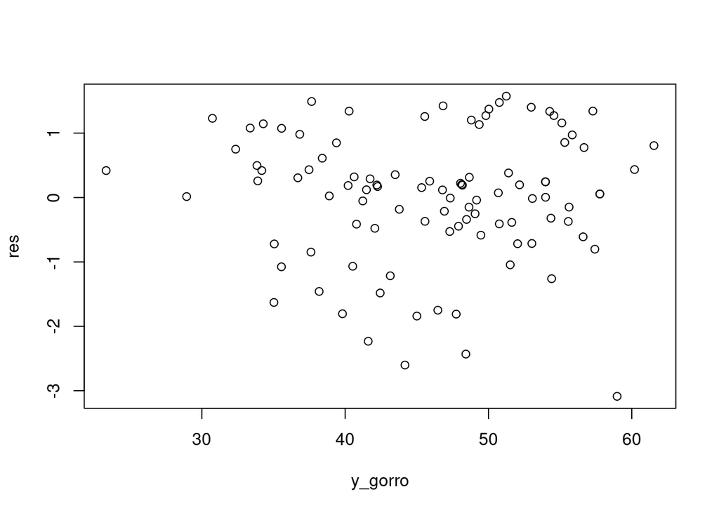

```r
res <- rstandard(mod1)
y_gorro <- mod1$fitted.values

plot(y_gorro, res)
```

No se distingue ninguna forma en la nube de puntos

## Ejercicio 6

```r
library("lmtest")
dwtest(mod1)
```

```
##
##  Durbin-Watson test
##
## data:  mod1
## DW = 1.8924, p-value = 0.3179
## alternative hypothesis: true autocorrelation is greater than 0
```

## Ejercicio 7

```r
kstestres <- ks.test(y_gorro, res)
kstestres
```

```
##
##  Two-sample Kolmogorov-Smirnov test
##
## data:  y_gorro and res
## D = 1, p-value < 2.2e-16
## alternative hypothesis: two-sided
```

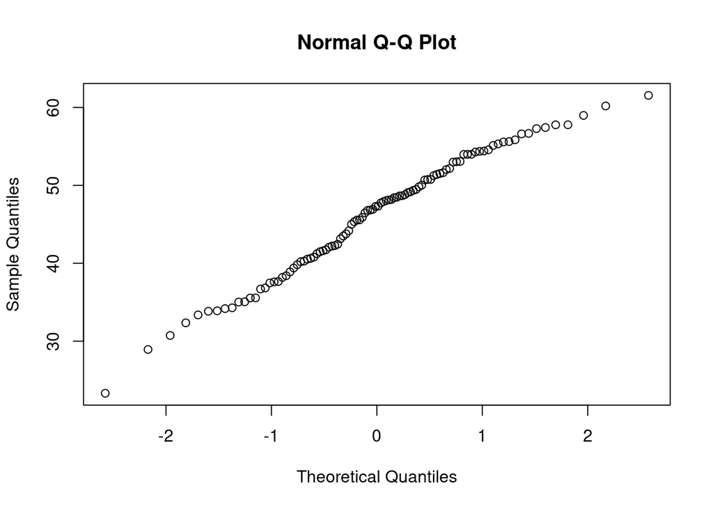

```r
qqnorm(y_gorro)
```

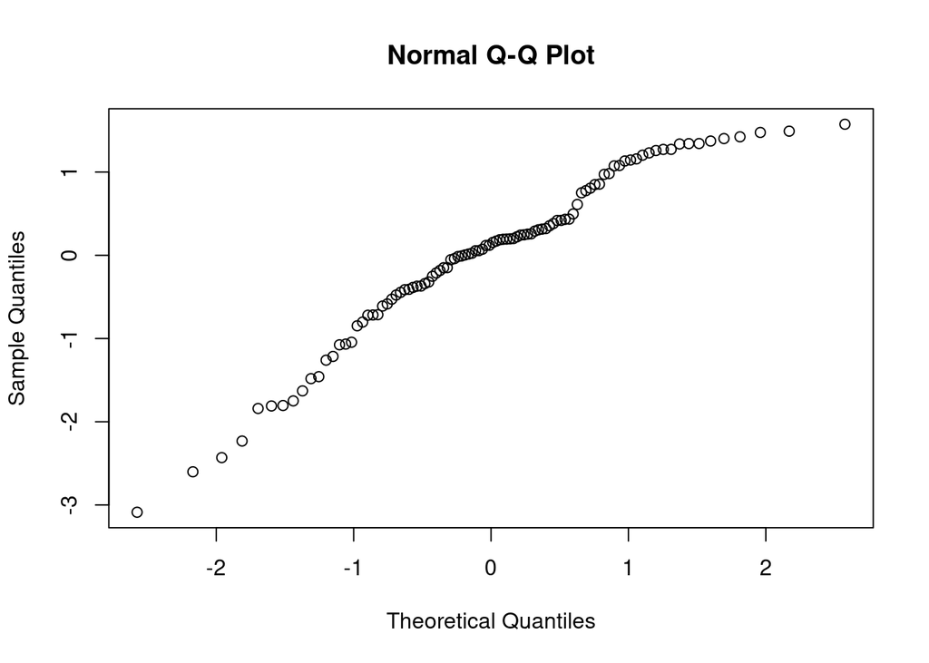

```r
qqnorm(res)
```

El qqnorm parece bastante lineal, luego parece que sigue una normal (mas o menos, siendo optimistas)

## Ejercicio 8

```r
library("car")
```

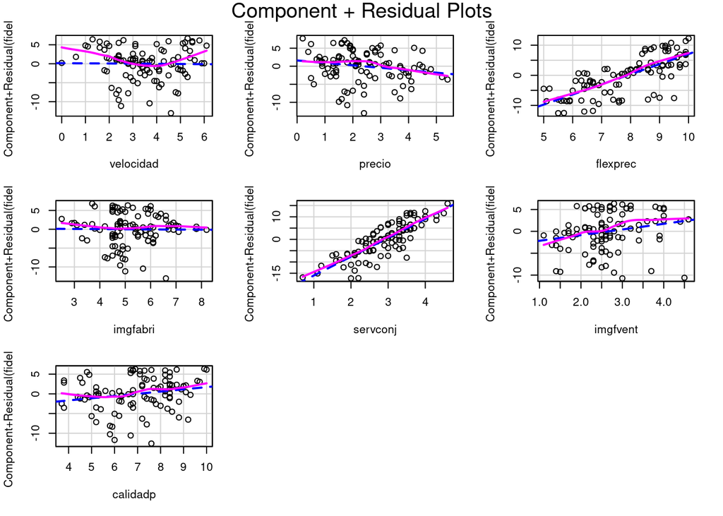

```r
crPlots(mod1)
```

## Ejercicio 9

Comenzamos identificando datos anómalos:

```r
res[abs(res) > 2.5]
```

```
##         7       100
## -3.087076 -2.601416
```

```r
hatco[abs(res) > 2.5, "empresa"]
```

```
## [1]   7 100
```

## Ejercicio 10

Ahora identificamos datos más influyentes:

```r
cooks.distance(mod1)
```

```
##            1            2            3            4            5            6
## 2.343629e-02 7.585226e-03 7.512616e-04 5.772721e-03 6.409789e-05 1.291961e-03
##            7            8            9           10           11           12
## 1.282814e-01 2.296811e-02 1.811987e-02 8.848250e-03 3.469765e-02 6.312789e-03
##           13           14           15           16           17           18
## 4.014997e-06 4.781522e-02 2.526948e-07 3.730999e-04 1.667707e-02 2.802366e-02
##           19           20           21           22           23           24
## 6.015212e-03 8.221856e-04 1.461057e-05 4.094587e-02 2.851590e-04 9.171460e-04
##           25           26           27           28           29           30
## 1.325656e-03 9.167320e-06 1.357325e-03 3.404872e-03 6.106876e-03 1.651425e-03
##           31           32           33           34           35           36
## 4.147314e-04 2.509657e-06 8.536057e-03 8.324728e-05 6.873463e-04 8.725582e-04
##           37           38           39           40           41           42
## 1.438149e-03 2.395974e-04 3.651921e-06 1.696356e-02 1.165774e-03 5.827170e-05
##           43           44           45           46           47           48
## 1.146508e-03 1.736730e-04 9.859573e-04 1.609839e-03 3.636217e-02 3.229431e-04
##           49           50           51           52           53           54
## 2.574559e-02 2.052560e-03 3.491998e-04 5.159255e-04 5.519979e-03 1.819412e-02
##           55           56           57           58           59           60
## 1.344517e-02 3.467779e-04 3.094989e-03 5.485554e-03 1.700423e-04 1.089096e-03
##           61           62           63           64           65           66
## 2.643229e-02 1.490702e-02 6.574685e-04 1.236862e-02 2.118805e-02 1.123670e-03
##           67           68           69           70           71           72
## 5.246231e-03 1.690142e-02 1.952767e-02 4.019917e-04 1.926918e-03 9.551961e-04
##           73           74           75           76           77           78
## 4.964432e-05 1.533933e-02 3.804694e-03 1.261229e-02 1.347379e-04 4.015896e-03
##           79           80           81           82           83           84
## 2.537450e-02 8.021309e-03 1.567445e-02 1.452640e-06 1.034581e-02 1.485785e-02
##           85           86           87           88           89           90
## 1.068583e-02 1.730713e-04 9.089012e-03 9.789529e-03 6.827437e-03 4.732818e-03
##           91           92           93           94           95           96
## 2.559365e-04 2.835121e-02 8.653919e-04 1.306852e-02 1.337443e-02 4.776408e-03
##           97           98           99          100
## 1.714914e-02 9.358314e-03 9.158967e-04 5.162698e-02
```

```r
hatvalues(mod1)
```

```
##          1          2          3          4          5          6          7
## 0.08102361 0.07759012 0.08643509 0.08174711 0.14000028 0.07582374 0.09721698
##          8          9         10         11         12         13         14
## 0.07628926 0.07439691 0.04662431 0.05279359 0.04423439 0.04806288 0.06080497
##         15         16         17         18         19         20         21
## 0.10052423 0.07462282 0.08284870 0.06404132 0.06958332 0.10052423 0.04008247
##         22         23         24         25         26         27         28
## 0.36747172 0.09417109 0.04004388 0.05958272 0.04497897 0.04203221 0.06823631
##         29         30         31         32         33         34         35
## 0.08677528 0.06240874 0.03778341 0.08094839 0.06735789 0.04564838 0.07605345
##         36         37         38         39         40         41         42
## 0.03928903 0.07771845 0.04060177 0.11316219 0.04865353 0.03926800 0.13405924
##         43         44         45         46         47         48         49
## 0.08200940 0.05867554 0.07737790 0.08550600 0.15236362 0.07213961 0.08636882
##         50         51         52         53         54         55         56
## 0.10119922 0.07425766 0.09552807 0.07982462 0.04276906 0.36553020 0.04112957
##         57         58         59         60         61         62         63
## 0.11593633 0.06318673 0.05391594 0.08083116 0.14132134 0.06856870 0.04355736
##         64         65         66         67         68         69         70
## 0.07995531 0.12801050 0.03129822 0.05425808 0.06984566 0.05926831 0.06108122
##         71         72         73         74         75         76         77
## 0.09378108 0.11197005 0.06946865 0.06417551 0.07536757 0.05975082 0.06906446
##         78         79         80         81         82         83         84
## 0.08598108 0.13402726 0.03292832 0.05992802 0.15260195 0.07906456 0.03389825
##         85         86         87         88         89         90         91
## 0.04046887 0.04528527 0.04387797 0.03441900 0.07071769 0.05908952 0.04800643
##         92         93         94         95         96         97         98
## 0.06899995 0.15472827 0.06461389 0.08465701 0.17876725 0.09278016 0.06040246
##         99        100
## 0.06642955 0.05752006
```

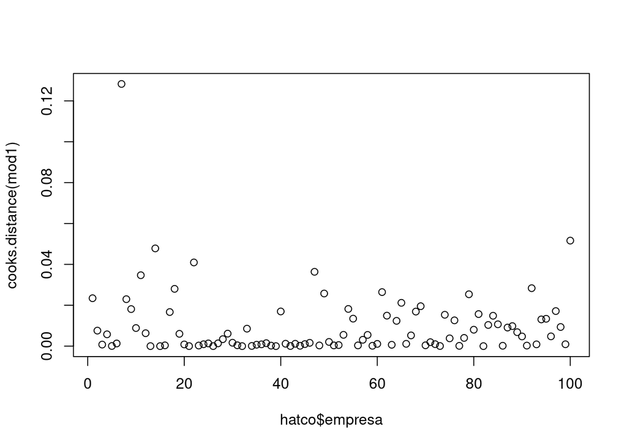

```r
plot(hatco$empresa, cooks.distance(mod1))
```

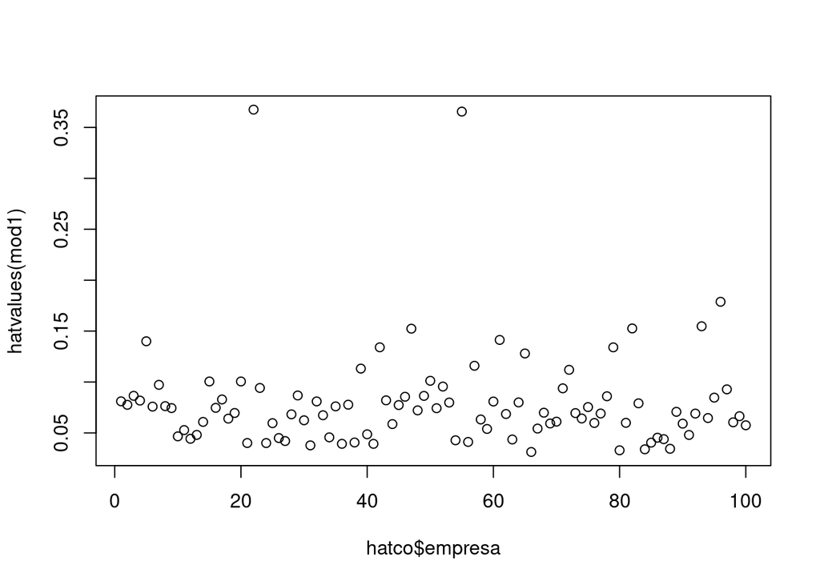

```r
plot(hatco$empresa, hatvalues(mod1))
```

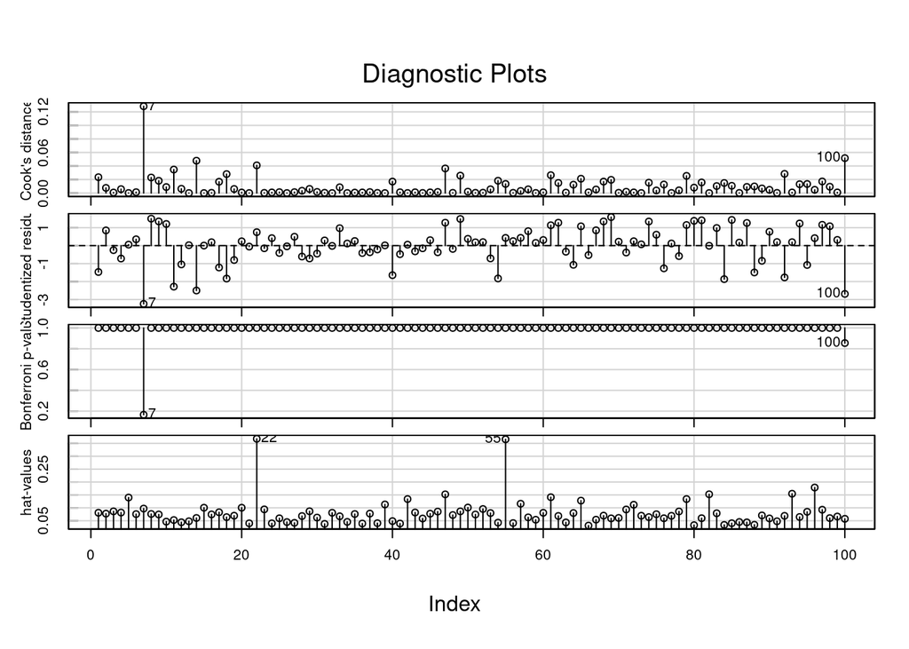

```r
influenceIndexPlot(mod1)
```

Vemos que las empresas más influyentes son las 7,22,55 y 100.

Además, del apartado anterior tenemos que la 7 y 100 son anómalas.

## Ejercicio 11

```r
hatco2 <- hatco[-c(7,100),]

mod3<-lm(fidelidad~precio+flexprec+imgfabri+servconj+imgfvent+calidadp,hatco2)
mod3
```

```
##
## Call:
## lm(formula = fidelidad ~ precio + flexprec + imgfabri + servconj +
##     imgfvent + calidadp, data = hatco2)
##
## Coefficients:
## (Intercept)       precio     flexprec     imgfabri     servconj     imgfvent
##    -12.2928      -0.4863       3.6133      -0.3712       8.0233       2.2363
##    calidadp
##      0.5578
```

```r
summary(mod3)
```

```
##
## Call:
## lm(formula = fidelidad ~ precio + flexprec + imgfabri + servconj +
##     imgfvent + calidadp, data = hatco2)
##
## Residuals:
##      Min       1Q   Median       3Q      Max
## -11.6097  -2.0571   0.4897   2.2503   6.7728
##
## Coefficients:
##             Estimate Std. Error t value Pr(>|t|)
## (Intercept) -12.2928     4.4824  -2.742  0.00734 **
## precio       -0.4863     0.5549  -0.877  0.38305
## flexprec      3.6133     0.3780   9.559 2.13e-15 ***
## imgfabri     -0.3712     0.6042  -0.614  0.54047
## servconj      8.0233     0.7595  10.563  < 2e-16 ***
## imgfvent      2.2363     0.8868   2.522  0.01342 *
## calidadp      0.5578     0.3249   1.717  0.08941 .
## ---
## Signif. codes:  0 '***' 0.001 '**' 0.01 '*' 0.05 '.' 0.1 ' ' 1
##
## Residual standard error: 4.022 on 91 degrees of freedom
## Multiple R-squared:  0.8119, Adjusted R-squared:  0.7995
## F-statistic: 65.46 on 6 and 91 DF,  p-value: < 2.2e-16
```

```r
anova(mod3)
```

```
## Analysis of Variance Table
##
## Response: fidelidad
##           Df Sum Sq Mean Sq  F value    Pr(>F)
## precio     1   46.2    46.2   2.8559  0.094464 .
## flexprec   1 3956.2  3956.2 244.5406 < 2.2e-16 ***
## imgfabri   1  348.9   348.9  21.5680 1.146e-05 ***
## servconj   1 1839.7  1839.7 113.7152 < 2.2e-16 ***
## imgfvent   1  115.7   115.7   7.1547  0.008865 **
## calidadp   1   47.7    47.7   2.9476  0.089408 .
## Residuals 91 1472.2    16.2
## ---
## Signif. codes:  0 '***' 0.001 '**' 0.01 '*' 0.05 '.' 0.1 ' ' 1
```

## Ejercicio 12

```r
R<-cor(hatco[,6:12])
ai<-eigen(R)$values # autovalores
sqrt(max(ai)/min(ai)) # indice IC
```

```
## [1] 16.60453
```

```r
vif(mod2)
```

```
##   precio flexprec imgfabri servconj imgfvent calidadp
## 2.667178 1.644170 2.815906 1.949074 2.687216 1.605686
```

## Ejercicio 13

```r
step(mod2)
```

```
## Start:  AIC=303.06
## fidelidad ~ precio + flexprec + imgfabri + servconj + imgfvent +
##     calidadp
##
##            Df Sum of Sq    RSS    AIC
## - imgfabri  1      0.07 1800.5 301.07
## - precio    1     21.44 1821.9 302.25
## <none>                  1800.5 303.06
## - imgfvent  1     36.44 1836.9 303.07
## - calidadp  1     49.08 1849.5 303.75
## - flexprec  1   1308.45 3108.9 355.69
## - servconj  1   1957.10 3757.6 374.64
##
## Step:  AIC=301.07
## fidelidad ~ precio + flexprec + servconj + imgfvent + calidadp
##
##            Df Sum of Sq    RSS    AIC
## - precio    1     21.53 1822.1 300.26
## <none>                  1800.5 301.07
## - calidadp  1     49.01 1849.5 301.75
## - imgfvent  1     82.68 1883.2 303.56
## - flexprec  1   1321.77 3122.3 354.12
## - servconj  1   1988.89 3789.4 373.48
##
## Step:  AIC=300.26
## fidelidad ~ flexprec + servconj + imgfvent + calidadp
##
##            Df Sum of Sq    RSS    AIC
## - calidadp  1     30.64 1852.7 299.92
## <none>                  1822.1 300.26
## - imgfvent  1     85.62 1907.7 302.85
## - flexprec  1   1931.03 3753.1 370.52
## - servconj  1   3073.67 4895.7 397.09
##
## Step:  AIC=299.92
## fidelidad ~ flexprec + servconj + imgfvent
##
##            Df Sum of Sq    RSS    AIC
## <none>                  1852.7 299.92
## - imgfvent  1    110.83 1963.5 303.73
## - flexprec  1   2145.75 3998.5 374.85
## - servconj  1   3044.78 4897.5 395.13
```

```
##
## Call:
## lm(formula = fidelidad ~ flexprec + servconj + imgfvent, data = hatco)
##
## Coefficients:
## (Intercept)     flexprec     servconj     imgfvent
##      -6.514        3.370        7.629        1.416
```

```r
step(mod2, direction='both')
```

```
## Start:  AIC=303.06
## fidelidad ~ precio + flexprec + imgfabri + servconj + imgfvent +
##     calidadp
##
##            Df Sum of Sq    RSS    AIC
## - imgfabri  1      0.07 1800.5 301.07
## - precio    1     21.44 1821.9 302.25
## <none>                  1800.5 303.06
## - imgfvent  1     36.44 1836.9 303.07
## - calidadp  1     49.08 1849.5 303.75
## - flexprec  1   1308.45 3108.9 355.69
## - servconj  1   1957.10 3757.6 374.64
##
## Step:  AIC=301.07
## fidelidad ~ precio + flexprec + servconj + imgfvent + calidadp
##
##            Df Sum of Sq    RSS    AIC
## - precio    1     21.53 1822.1 300.26
## <none>                  1800.5 301.07
## - calidadp  1     49.01 1849.5 301.75
## + imgfabri  1      0.07 1800.5 303.06
## - imgfvent  1     82.68 1883.2 303.56
## - flexprec  1   1321.77 3122.3 354.12
## - servconj  1   1988.89 3789.4 373.48
##
## Step:  AIC=300.26
## fidelidad ~ flexprec + servconj + imgfvent + calidadp
##
##            Df Sum of Sq    RSS    AIC
## - calidadp  1     30.64 1852.7 299.92
## <none>                  1822.1 300.26
## + precio    1     21.53 1800.5 301.07
## + imgfabri  1      0.16 1821.9 302.25
## - imgfvent  1     85.62 1907.7 302.85
## - flexprec  1   1931.03 3753.1 370.52
## - servconj  1   3073.67 4895.7 397.09
##
## Step:  AIC=299.92
## fidelidad ~ flexprec + servconj + imgfvent
##
##            Df Sum of Sq    RSS    AIC
## <none>                  1852.7 299.92
## + calidadp  1     30.64 1822.1 300.26
## + precio    1      3.16 1849.5 301.75
## + imgfabri  1      0.01 1852.7 301.92
## - imgfvent  1    110.83 1963.5 303.73
## - flexprec  1   2145.75 3998.5 374.85
## - servconj  1   3044.78 4897.5 395.13
```

```
##
## Call:
## lm(formula = fidelidad ~ flexprec + servconj + imgfvent, data = hatco)
##
## Coefficients:
## (Intercept)     flexprec     servconj     imgfvent
##      -6.514        3.370        7.629        1.416
```

Además, se observa que las reducciones para atrás y con el argumento both devuelven exactamente el mismo resultado.